# Кластерный анализ в R

Заходякин Г.В., postlogist@gmail.com

12 мая 2017 г

```r
library(tidyverse) # манипулирование данными и визуализация
#install.packages("NbClust") # пакет не входит в стандартный дистрибутив для курса
library(NbClust) # определение числа кластеров
#install.packages("factoextra") # пакет не входит в стандартный дистрибутив для курса
library(factoextra) # визуализация кластеров с помощью ggplot2
library(GGally) # визуализация в параллельных координатах
```

# Подготовка

Загрузка данных

```r
d <- read_csv('churn.txt')
glimpse(d)
```

```
## Observations: 3,333
## Variables: 21
## $ state                <chr> "KS", "OH", "NJ", "OH", "OK", "AL", "MA",...
## $ account_length       <dbl> 128, 107, 137, 84, 75, 118, 121, 147, 117...
## $ area_code            <dbl> 415, 415, 415, 408, 415, 510, 510, 415, 4...
## $ phone                <chr> "382-4657", "371-7191", "358-1921", "375-...
## $ international_plan   <chr> "no", "no", "no", "yes", "yes", "yes", "n...
## $ voicemail_plan       <chr> "yes", "yes", "no", "no", "no", "no", "ye...
## $ voicemail_message    <dbl> 25, 26, 0, 0, 0, 0, 24, 0, 0, 37, 0, 0, 0...
## $ day_mins             <dbl> 265.1, 161.6, 243.4, 299.4, 166.7, 223.4,...
## $ day_calls            <dbl> 110, 123, 114, 71, 113, 98, 88, 79, 97, 8...
## $ day_charge           <dbl> 45.07, 27.47, 41.38, 50.90, 28.34, 37.98,...
## $ evening_mins         <dbl> 197.4, 195.5, 121.2, 61.9, 148.3, 220.6, ...
## $ evening_calls        <dbl> 99, 103, 110, 88, 122, 101, 108, 94, 80, ...
## $ evening_charge       <dbl> 16.78, 16.62, 10.30, 5.26, 12.61, 18.75, ...
## $ night_mins           <dbl> 244.7, 254.4, 162.6, 196.9, 186.9, 203.9,...
## $ night_calls          <dbl> 91, 103, 104, 89, 121, 118, 118, 96, 90, ...
## $ night_charge         <dbl> 11.01, 11.45, 7.32, 8.86, 8.41, 9.18, 9.5...
## $ international_mins   <dbl> 10.0, 13.7, 12.2, 6.6, 10.1, 6.3, 7.5, 7....
## $ international_calls  <dbl> 3, 3, 5, 7, 3, 6, 7, 6, 4, 5, 6, 5, 2, 5,...
## $ international_charge <dbl> 2.70, 3.70, 3.29, 1.78, 2.73, 1.70, 2.03,...
## $ custserv_calls       <dbl> 1, 1, 0, 2, 3, 0, 3, 0, 1, 0, 4, 0, 1, 3,...
## $ churn                <lgl> FALSE, FALSE, FALSE, FALSE, FALSE, FALSE,...
```

Расчет потребления клиентом услуг в долевом выражении

```r
dprep <- d %>%
  mutate(percent_dmins = 100 * day_mins / (day_mins + evening_mins + night_mins),
         percent_emins = 100 * evening_mins / (day_mins + evening_mins + night_mins),
         percent_nmins = 100 * night_mins / (day_mins + evening_mins + night_mins),
         percent_intmins = 100 * international_mins / (day_mins + evening_mins + night_mins),
         totmins = day_mins + evening_mins + night_mins,
         totcalls = day_calls + evening_calls + night_calls,
         intplan = if_else(international_plan == "yes", 1, 0),
         vmplan = if_else(voicemail_plan == "yes", 1, 0))
```

Отбор переменных для построения клиентских профилей

```r
dselect <- dprep %>%
  select(account_length, percent_emins, percent_nmins, percent_intmins, totmins, totcalls, intplan, vmplan, custserv_calls)
#nb: не отбираем percent_dmins, т.к. столбцы nmins, emins и dmins линейно зависимы
glimpse(dselect)
```

```
## Observations: 3,333
## Variables: 9
## $ account_length  <dbl> 128, 107, 137, 84, 75, 118, 121, 147, 117, 141...
## $ percent_emins   <dbl> 27.91290, 31.97056, 22.98938, 11.08922, 29.547...
## $ percent_nmins   <dbl> 34.60124, 41.60262, 30.84219, 35.27410, 37.238...
## $ percent_intmins <dbl> 1.4140271, 2.2403925, 2.3141123, 1.1823719, 2....
## $ totmins         <dbl> 707.2, 611.5, 527.2, 558.2, 501.9, 647.9, 779....
## $ totcalls        <dbl> 300, 329, 328, 248, 356, 317, 314, 269, 267, 2...
## $ intplan         <dbl> 0, 0, 0, 1, 1, 1, 0, 1, 0, 1, 0, 0, 0, 0, 0, 0...
## $ vmplan          <dbl> 1, 1, 0, 0, 0, 0, 1, 0, 0, 1, 0, 0, 0, 0, 0, 0...
## $ custserv_calls  <dbl> 1, 1, 0, 2, 3, 0, 3, 0, 1, 0, 4, 0, 1, 3, 4, 4...
```

Приведение всех переменных к одному масштабу с помощью стандартизации

```r
dscaled <- scale(dselect)
```

Визуализация распределений переменных. Для сопоставимости, используем стандартизованные значения переменных.

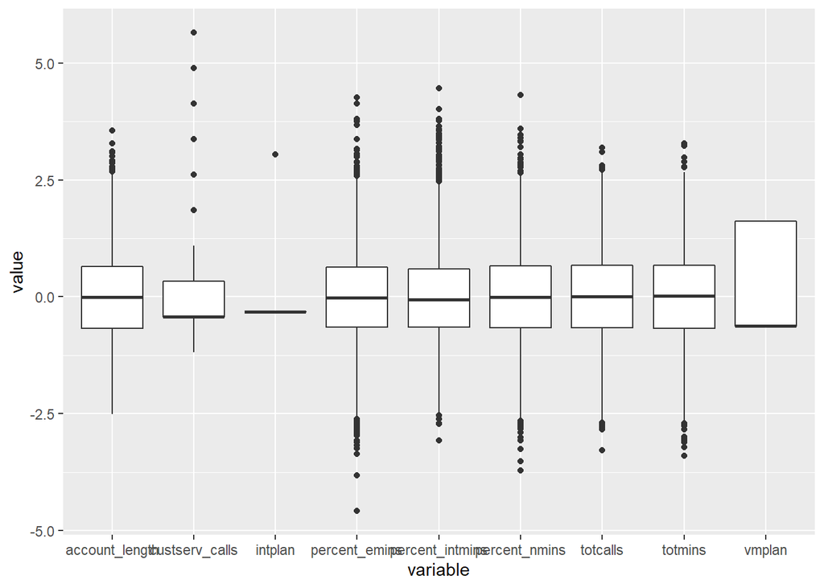

```r
dscaled_tall <- dscaled %>% as_tibble() %>% gather(key = "variable")
ggplot(data = dscaled_tall, aes(x = variable, y = value)) +
  geom_boxplot()
```

# Выделение и анализ кластеров

Выделение кластеров

```r
set.seed(123)
cl <- kmeans(dscaled, centers = 3)
names(cl)
```

```
## [1] "cluster"      "centers"      "totss"        "withinss"
## [5] "tot.withinss" "betweenss"    "size"         "iter"
## [9] "ifault"
```

Размеры кластеров

```r
cl$size
```

```
## [1]  966 1360 1007
```

Кластеры примерно одинакового размера.

Центроиды кластеров

```r
cl$centers %>% t() %>% round(3)
```

```
##                      1      2      3
## account_length   0.000 -0.055  0.074
## percent_emins   -0.716 -0.129  0.861
## percent_nmins    0.867 -0.003 -0.827
## percent_intmins  0.551 -0.703  0.421
## totmins         -0.657  0.815 -0.470
## totcalls         0.005  0.059 -0.084
## intplan         -0.090 -0.072  0.183
## vmplan           0.002  0.016 -0.023
## custserv_calls   0.120 -0.079 -0.009
```

Визуализация различий между центроидами кластеров

Подготовка данных

```r
centroids_tall <- cl$centers %>%
  as_tibble() %>%
  mutate(cluster = rownames(cl$centers)) %>%
  gather(key = var, value = value, account_length:custserv_calls)
```

Визуализация центроидов с помощью столбиковых диаграмм

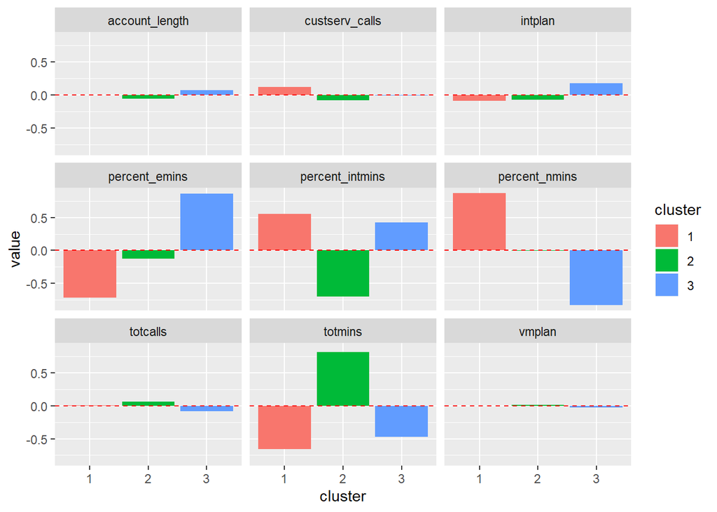

```r
ggplot(data = centroids_tall,
       aes(x = cluster, y = value, fill = cluster)) +
  geom_bar(stat = "identity") +
  geom_hline(yintercept = 0, colour = "red", linetype = "dashed") +
  facet_wrap(~ var, ncol = 3)
```

Визуализация центроидов с помощью диаграмм в параллельных координатах

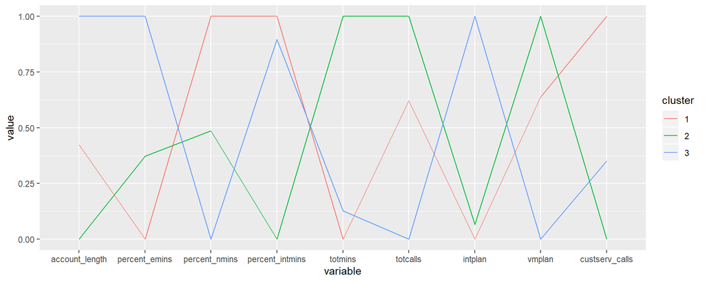

```r
centroids <- cl$centers %>%
  as.data.frame() %>%
  mutate(cluster = rownames(cl$centers))

ggparcoord(centroids, columns = 1:9,
           groupColumn = "cluster",
           scale = "uniminmax") #+ coord_flip()
```

Визуализация членства в кластерах для наблюдений. Метод использует проекцию данных из многомерного пространства признаков на плоскость из двух главных компонент.

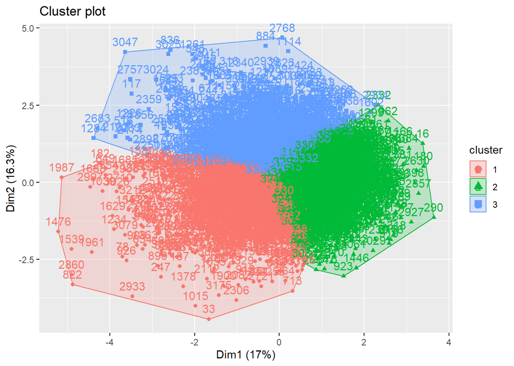

```r
fviz_cluster(cl, data = dselect)
```

Распределение переменных из исходной таблицы данных в кластерах

Подготовка данных - добавление номера кластера к исходной таблице

```r
dprep_cl <- dprep %>%
  mutate(cluster = factor(cl$cluster))
```

Визуализация распределения целевой переменной

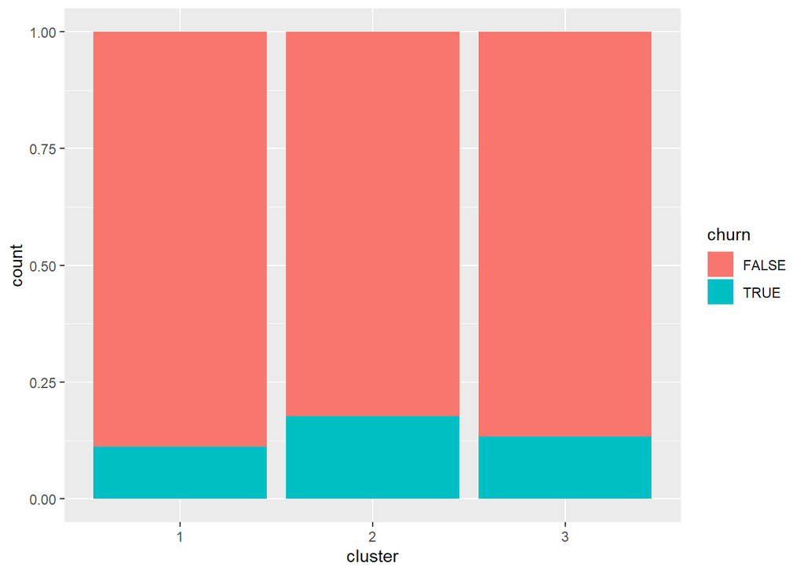

```r
ggplot(dprep_cl, aes(x = cluster)) +
  geom_bar(aes(fill = churn), position = "fill")
```

Распределение характеристик клиента в кластерах

С помощью диаграммы в параллельных координатах

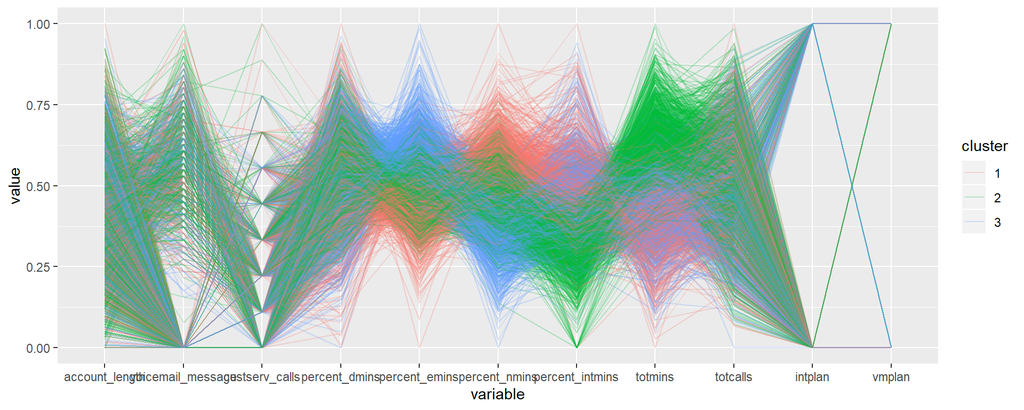

```r
ggparcoord(dprep_cl, columns = c(2, 7, 20, 22:29),
           groupColumn = "cluster",
           scale = "uniminmax",
           alphaLines = 0.25) #+ coord_flip()
```

С помощью средних

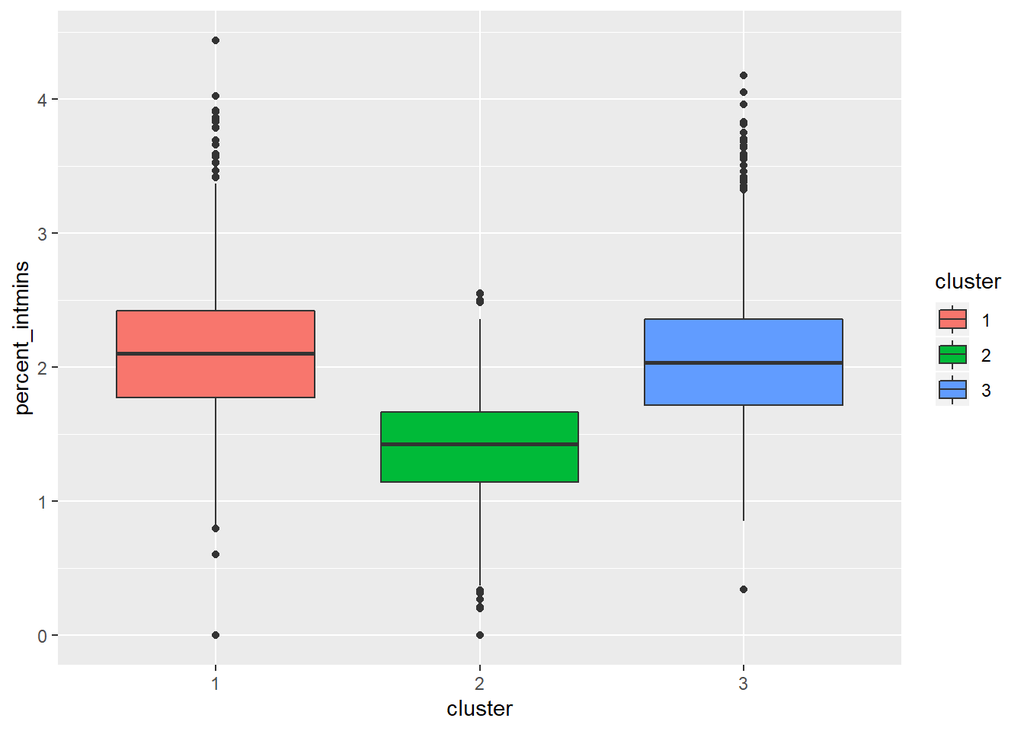

```r
ggplot(dprep_cl, aes(x = cluster, y = percent_intmins)) +
  geom_boxplot(aes(fill = cluster))
```

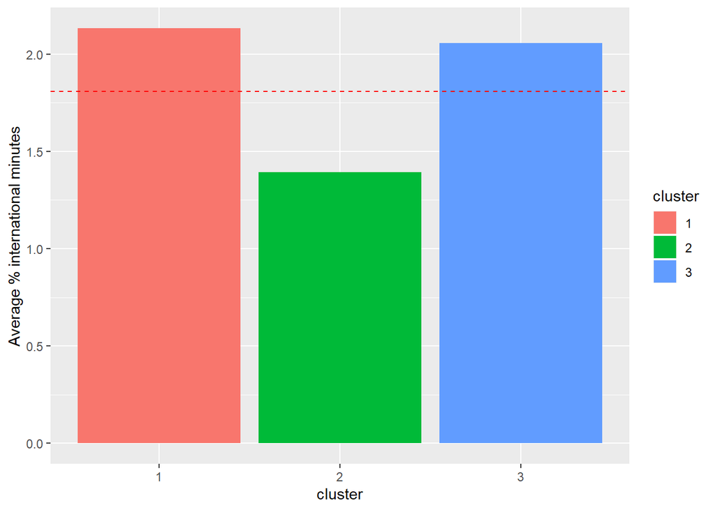

```r
ggplot(dprep_cl, aes(x = cluster, y = percent_intmins, fill = cluster)) +
  stat_summary(fun.y = "mean", geom = "bar") +
  geom_hline(aes(yintercept = mean(percent_intmins)),
             color = "red", linetype = "dashed") +
  labs(y = "Average % international minutes")
```

# Подбор оптимального числа кластеров

Функции для подбора числа кластеров k содержатся в пакетах `factoextra` и `NbClust`

Функция fviz_nbclust() может строить графики для показателей качества кластеризации в зависимости от k.

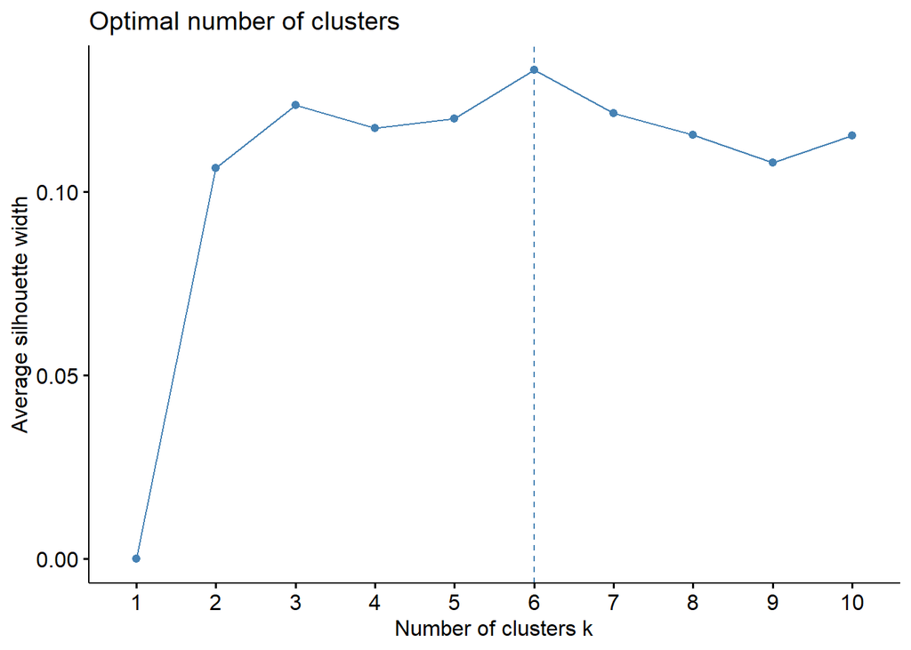

```r
fviz_nbclust(dscaled, FUNcluster = kmeans)
```

При использовании показателя average silhouette width https://en.wikipedia.org/wiki/Silhouette_(clustering) оптимальным является число кластеров 6 или 3. Хотя при 6 кластерах разделение несколько лучше, большое число кластеров сложнее интерпретировать.

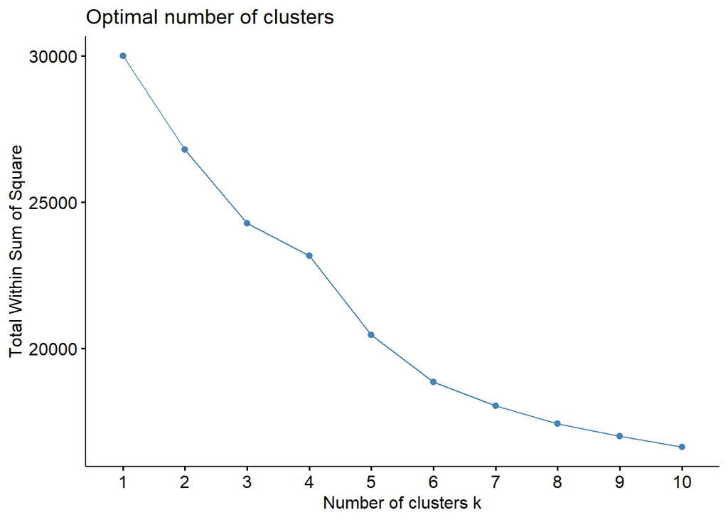

```r
fviz_nbclust(dscaled, FUNcluster = kmeans, method = "wss")
```

При использовании показателя within sum of squares (дисперсия внутри кластера) следует искать точку перегиба на кривой, в которой начинает работать “закон убывающей отдачи”, т.е. дисперсия внутри кластеров начинает медленнее снижаться с ростом k. В данном случае явного порога не наблюдается, в качестве возможного варианта можно использовать 3-5 кластеров.

Функция `NbClust()` одноименного пакета вычисляет сразу 26 показателей качества кластеризации. Оптимальное число кластеров выбирается с помощью “голосования”.

```r
set.seed(123)
ids <- sample(nrow(dscaled), size = 300) #Очень долго работает на всем наборе данных
cl_nb <- NbClust(data = dscaled[ids, ], distance = "euclidean",
                  min.nc = 2, max.nc = 9,
                  method = "kmeans", index = "all")
```

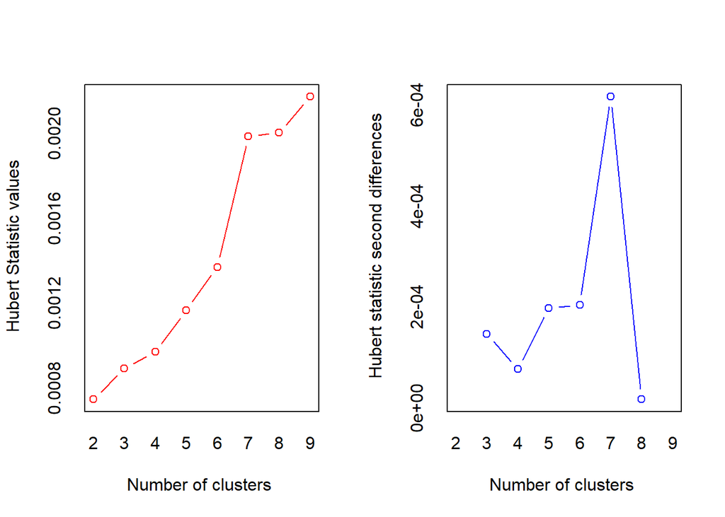

```
## *** : The Hubert index is a graphical method of determining the number of clusters.
##                 In the plot of Hubert index, we seek a significant knee that corresponds to a
##                 significant increase of the value of the measure i.e the significant peak in Hubert
##                 index second differences plot.
##
```

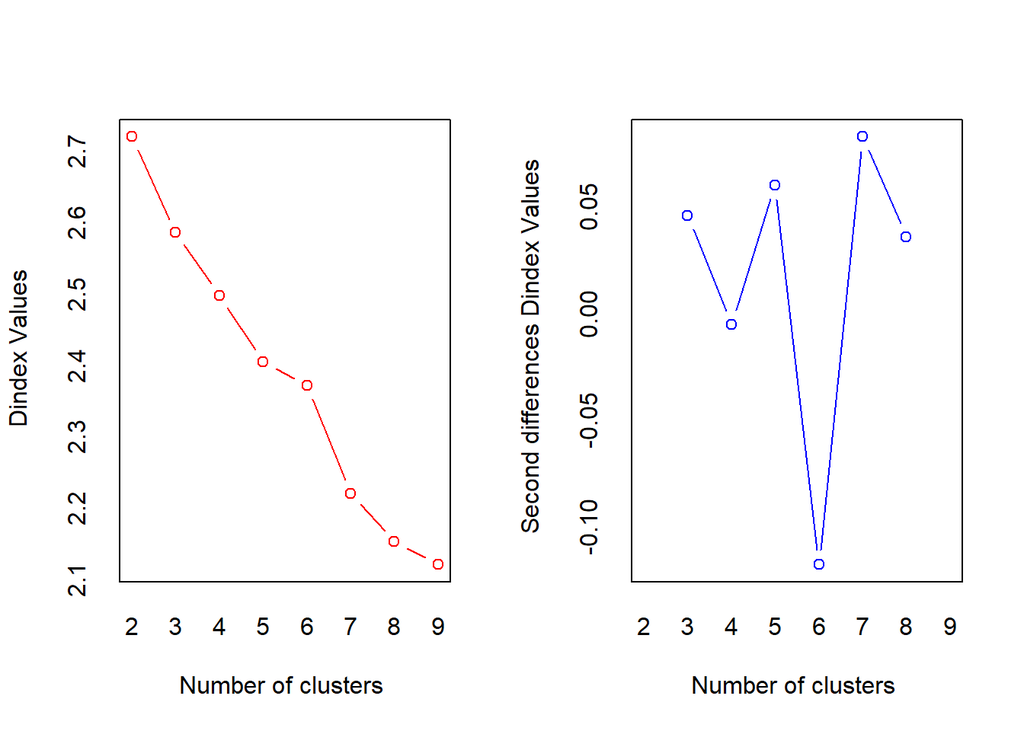

```
## *** : The D index is a graphical method of determining the number of clusters.
##                 In the plot of D index, we seek a significant knee (the significant peak in Dindex
##                 second differences plot) that corresponds to a significant increase of the value of
##                 the measure.
##
## * Among all indices:
## * 6 proposed 2 as the best number of clusters
## * 2 proposed 3 as the best number of clusters
## * 1 proposed 5 as the best number of clusters
## * 1 proposed 6 as the best number of clusters
## * 5 proposed 7 as the best number of clusters
## * 4 proposed 8 as the best number of clusters
## * 4 proposed 9 as the best number of clusters
##
##                    ***** Conclusion *****
##
## * According to the majority rule, the best number of clusters is  2
##
##
```

```
## Among all indices:
## ===================
## * 2 proposed  0 as the best number of clusters
## * 1 proposed  1 as the best number of clusters
## * 6 proposed  2 as the best number of clusters
## * 2 proposed  3 as the best number of clusters
## * 1 proposed  5 as the best number of clusters
## * 1 proposed  6 as the best number of clusters
## * 5 proposed  7 as the best number of clusters
## * 4 proposed  8 as the best number of clusters
## * 4 proposed  9 as the best number of clusters
##
## Conclusion
## =========================
## * According to the majority rule, the best number of clusters is  2 .
```

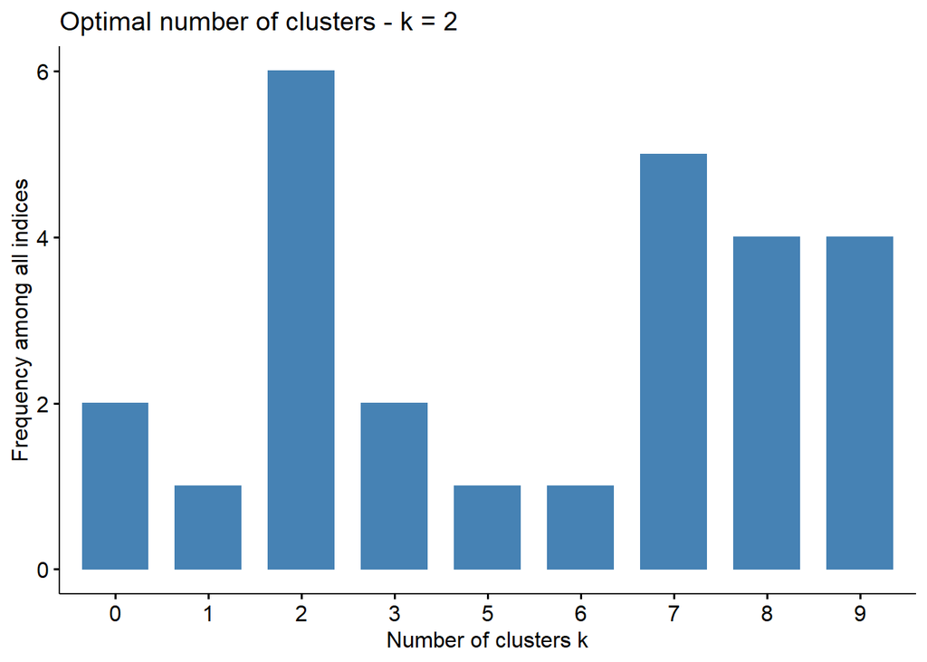

```r
fviz_nbclust(cl_nb)
```